# R Notebook

```r
library(GGally)
```

# Question 1

| ...1 | passenger_id | pclass | name | sex | age | sib_sp | parch | ticket | fare | cabin | embarked | survived |
| --- | --- | --- | --- | --- | --- | --- | --- | --- | --- | --- | --- | --- |
| 681 | 263 | 1 | Taussig, Mr. Emil | male | 52.00 | 1 | 1 | 110413 | 79.6500 | E67 | S | 0 |
| 1052 | 634 | 1 | Parr, Mr. William Henry Marsh | male | NA | 0 | 0 | 112052 | 0.0000 | NA | S | 0 |
| 832 | 414 | 2 | Cunningham, Mr. Alfred Fleming | male | NA | 0 | 0 | 239853 | 0.0000 | NA | S | 0 |
| 1288 | 870 | 3 | Johnson, Master. Harold Theodor | male | 4.00 | 1 | 1 | 347742 | 11.1333 | NA | S | 1 |
| 577 | 159 | 3 | Smiljanic, Mr. Mile | male | NA | 0 | 0 | 315037 | 8.6625 | NA | S | 0 |
| 1299 | 881 | 2 | Shelley, Mrs. William (Imanita Parrish Hall) | female | 25.00 | 0 | 1 | 230433 | 26.0000 | NA | S | 1 |
| 1289 | 871 | 3 | Balkic, Mr. Cerin | male | 26.00 | 0 | 0 | 349248 | 7.8958 | NA | S | 0 |
| 1124 | 706 | 2 | Morley, Mr. Henry Samuel ("Mr Henry Marshall") | male | 39.00 | 0 | 0 | 250655 | 26.0000 | NA | S | 0 |
| 1307 | 889 | 3 | Johnston, Miss. Catherine Helen "Carrie" | female | NA | 1 | 2 | W./C. 6607 | 23.4500 | NA | S | 0 |
| 786 | 368 | 3 | Moussa, Mrs. (Mantoura Boulos) | female | NA | 0 | 0 | 2626 | 7.2292 | NA | C | 1 |

[output cut: 881 more lines]

```r
titanic_clean <- titanic_set %>%
  mutate(sex = as.factor(sex),
         age_cat = as.factor(if_else(age <= 16, "child", "adult")),
         class = factor(pclass, levels = c(3,2,1), labels = c("lower", "middle", "upper")),
           survived = factor(survived, levels = c(0,1), labels = c("no", "yes")),
           port_embark = as.factor(embarked)) %>%
  select(sex, age_cat, class, port_embark, sib_sp, parch, survived) %>%
  na.omit()
```

# Question 2

[output not shown]

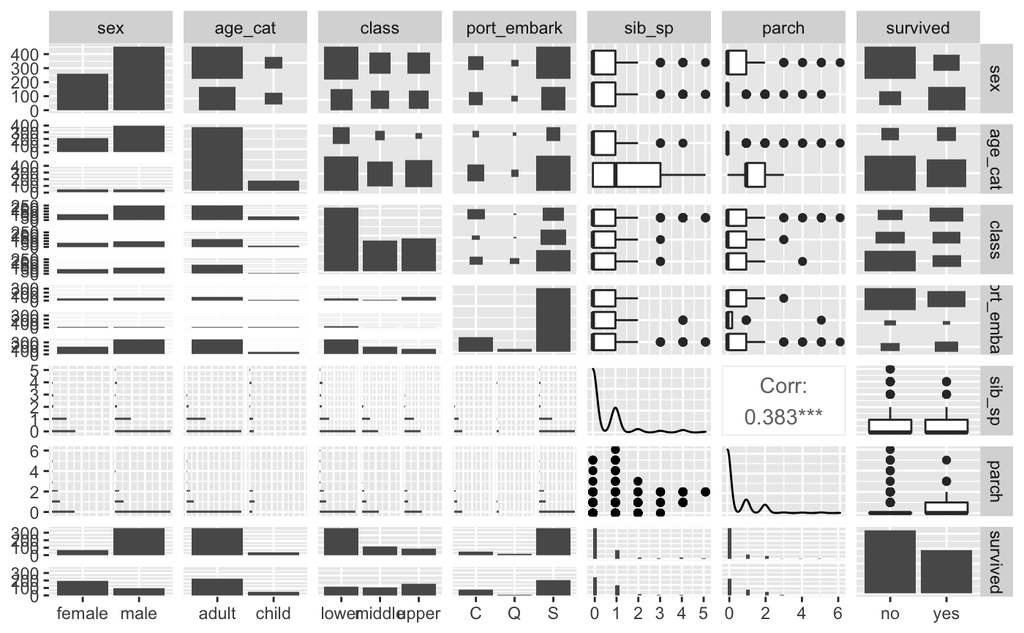

```r
ggpairs(titanic_clean)
```

**Interpretation**

From this pairs plot it appears that possible variables to predict whether or not people are going to die could be:

- class
- sex
- age_cat

# Question 3

```r
n_data <- nrow(titanic_clean)
test_index <- sample(1:n_data, size = n_data * 0.2)
titanic_test <- slice(titanic_clean, test_index)
titanic_train <- slice(titanic_clean, -test_index)
```

I chose an 80/20 split for my train/test as there would still be a valid number of observations in the test split, 142. That seems sufficient to test on.

```r
titanic_train %>%
  janitor::tabyl(survived)
```

```
 survived   n   percent
       no 340 0.5964912
      yes 230 0.4035088
```

```r
titanic_test %>%
  janitor::tabyl(survived)
```

```
 survived  n   percent
       no 84 0.5915493
      yes 58 0.4084507
```

# Question 4

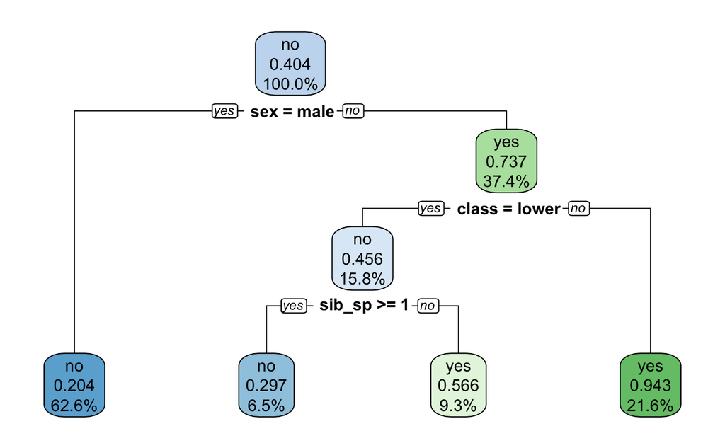

```r
# decision tree for titanic train data
titanic_tree <- rpart(
  formula = survived ~ .,
  data = titanic_train,
  method = "class"
)

rpart.plot(titanic_tree,
           yesno = 2,
           fallen.leaves = TRUE,
           faclen = 6,
           digits = 3)
```

# Question 5

This decision tree tells us the important features (variables) are:

- sex (root)
- class (intermediate)
- sib_sp

as these were the chosen features for my decision tree.

The root node tells us that 40.4% survived from the whole train data set. From there, given sex is male then 20.4% survived, given female, 73.7% survived.

If they were female, given they were not in lower class, survival was at 94.3%. Compared to a survival of 45.6% if they were female and in lower class.

Finally, if female and in lower class, survival was 29.7% if they had siblings or spouses on board. If they had no siblings or spouses on board, survival was 56.6%.

Overall, it appears that being a female in middle or upper class lead to the best chance of survival!

# Question 6

| sex | age_cat | class | port_embark | sib_sp | parch | survived | pred |
| --- | --- | --- | --- | --- | --- | --- | --- |
| male | adult | lower | S | 0 | 0 | no | no |
| female | child | middle | S | 0 | 2 | yes | yes |
| male | child | lower | S | 4 | 2 | no | no |
| male | adult | upper | S | 3 | 2 | no | no |
| male | adult | middle | S | 0 | 0 | no | no |
| male | adult | upper | C | 0 | 0 | no | no |
| male | adult | lower | S | 0 | 0 | no | no |
| male | adult | lower | C | 1 | 0 | no | no |
| male | child | lower | Q | 4 | 1 | no | no |
| male | adult | lower | S | 0 | 0 | no | no |

[output cut: 132 more lines]

```r
library(yardstick)

conf_matrix <- titanic_test_pred %>%
  conf_mat(truth = survived, estimate = pred)

conf_matrix
```

```
          Truth
Prediction no yes
       no  80  25
       yes  4  33
```

```r
titanic_test_pred %>%
  accuracy(truth = survived, estimate = pred)
```

| .metric | .estimator | .estimate |
| --- | --- | --- |
| accuracy | binary | 0.7957746 |

**Interpretation**

Main diagonal shows us our correctly predicted values (FF and TT). The greater these values, the better for our model. In my model they are substantial enough for me to conclude this model does a ‘decent’ job at predicting survival.

In this data set it tells me that I correctly predicted 80 people would not survive and 33 people would survive.

In fact, the accuracy comes out to 80% accuracy. 80% correctly predicted results.

With further time I could refine this model to boost the main diagonal further, bring down the false positives and negatives in the other diagonal.